# Species accumulation curves

So I ran my univariate models with the camera data, which was nice and all. But that means I have new work to do:

1. Add missing models are re-run.
   - Prerequisites:
     - choose canopy cover categories
     - make canopy cover rasters
     - make older forest rasters
2. Fix some stuff I’ve been doing wrong.
   - remake landcover rasters at 100m scale
   - rerun diet breakdown with counts Next steps:
   - compare counts and biomass breakdowns
3. Run the models also for physical specimen data.
   - Prerequisites:
     - finish cleaning physical data
     - determine if there’s a cutoff for sample size
   - Next steps:
     - compare results from camera and physical data
4. Compare diet between coastal and transition zones.
   - Prerequisites:
     - assign each site to cs or tz
   - Next steps:
     - compare results from camera and physical data

I’m going to start with the sample sizes.

```r
# Import conflict settings.
source('../src/conflicted.R')

# Load some libraries.
library(tidyverse)
library(lubridate)
library(vegan)

# Bring in data.
source('../src/prey_attributes_revised.R')
```

I want to know how many items need to be identified before I’ve identified all the items I’m going to identify. In other words, how many IDs are needed to give me a pretty complete picture of species richness. For the entire study area, I can trick `vegan` into doing this with `specaccum()` if I treat every item like a site.

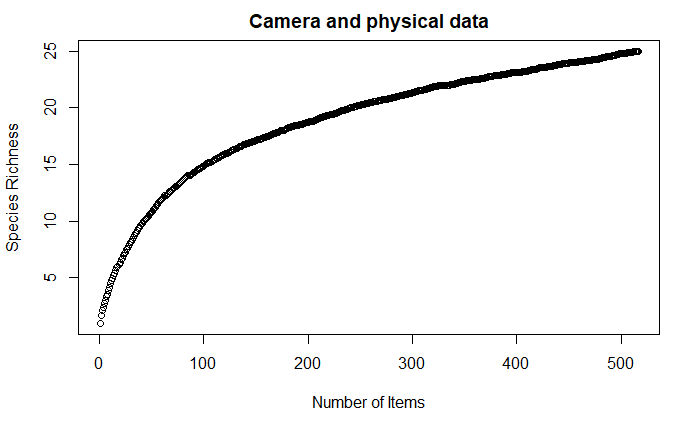

```r
fakecamera <- diet.items %>% filter(binomial != 'Unidentified item') %>%
  mutate(count=1, index=1:nrow(.)) %>%
  dplyr::select(index, binomial, count) %>%
  pivot_wider(names_from=binomial, values_from=count,
              values_fill=list(count = 0))

cameraaccum <- specaccum(fakecamera[, -1], method="random", permutations=100)

plot(cameraaccum$sites, cameraaccum$richness,
     xlab="Number of Items",
     ylab="Species Richness",
     main="Camera and physical data")
```

Which is a bit depressing to look at. But of course it’s also a bit misleading, because more species are present in the study area than are present at each site.

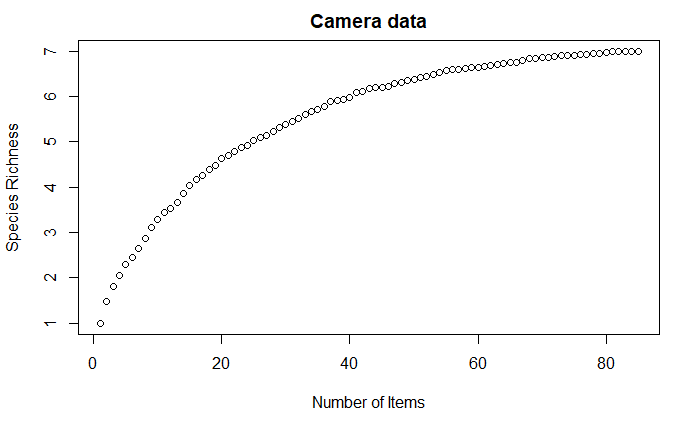

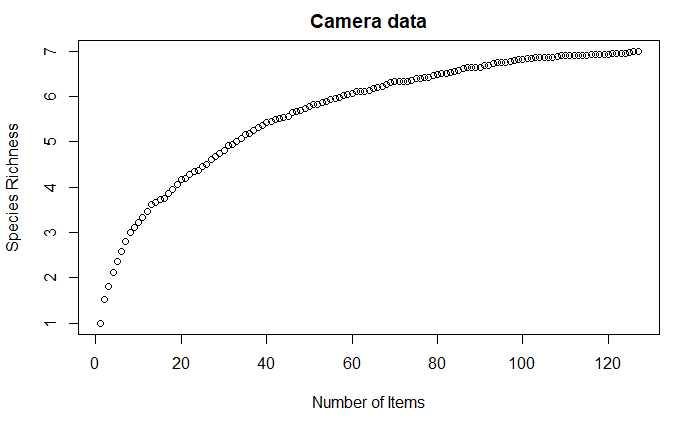

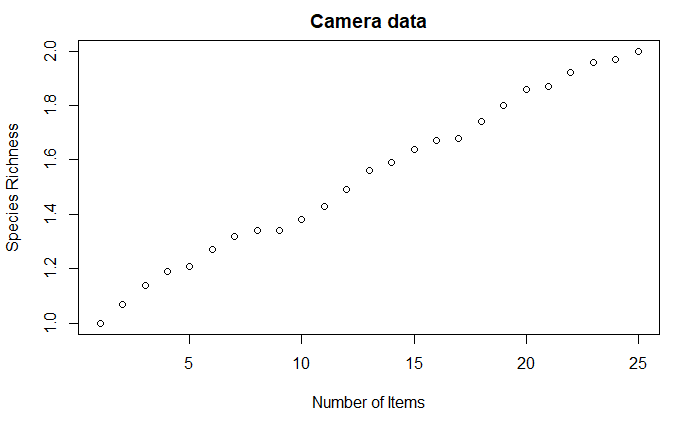

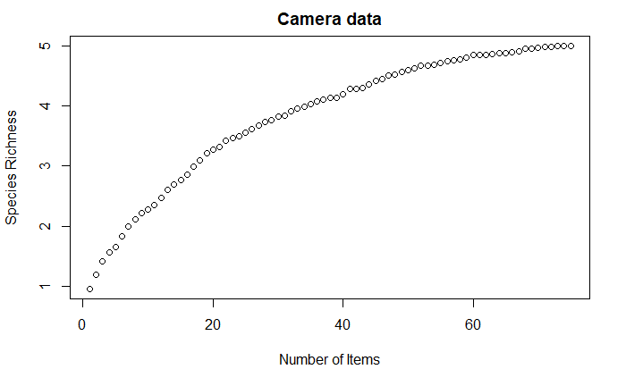

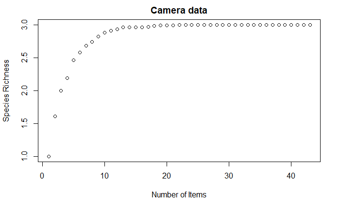

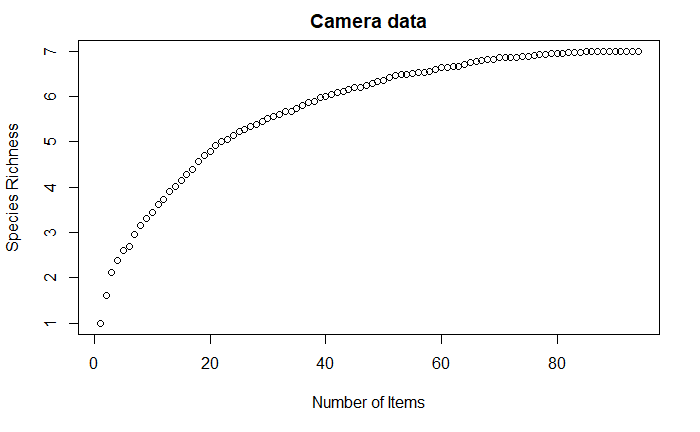

```r
fakecamera.sites <- diet.items %>% filter(binomial != 'Unidentified item' & method == 'camera') %>%
  mutate(count=1, index=1:nrow(.)) %>%
  dplyr::select(site, index, binomial, count) %>%
  pivot_wider(names_from=binomial, values_from=count,
              values_fill=list(count = 0))

fake.sites <- fakecamera.sites %>% group_by(site) %>%
  group_map(~specaccum(.x[3:17], method="random", permutations=100))

fake.sites %>% map(~plot(.$sites, .$richness,
              xlab="Number of Items",
              ylab="Species Richness",
              main="Camera data"))
```

Ok, that’s absolutely fascinating. There’s a lot more variation here than I was expecting. Eyeballing it, it does look like at around 50 items things start to level off, generally. Which is a problem, because I doubt most remains sites have 50 items!

Garcia-Salgado 2015 uses a minimum of 15 pellets (which is ridiculous) and 20 remains or camera items. So I have an excuse to use much smaller numbers than 50, but I’m not sure how confident I am in it.

Here’s how many things I have from the physical data:

```r
diet.items %>% filter(binomial != 'Unidentified item' & method == 'remains') %>%
  group_by(site) %>%
  summarize(n.items=n())
```

| site | n.items |
| --- | --- |
| BKH | 4 |
| DGC | 2 |
| GMT | 1 |
| MPT | 10 |
| MTC | 2 |
| MTF | 6 |
| PCR | 7 |
| PNC | 2 |
| PTL | 4 |
| RLK | 11 |

[output cut: 4 more lines]

So even with Garcia-Salgado’s very permissive definition of “complete picture of diet” I can’t do diversity and overlap-type things with these data. Of course, the total number of things is much higher:

```r
diet.items %>% filter(class != 'U' & method == 'remains') %>%
  group_by(site) %>%
  summarize(n.items=n())
```

| site | n.items |
| --- | --- |
| BKH | 5 |
| COM | 1 |
| DCR | 1 |
| DGC | 4 |
| GMT | 1 |
| HKO | 2 |
| MPT | 14 |
| MTC | 3 |
| MTF | 11 |
| PCR | 20 |

[output cut: 9 more lines]

Oh jeez, even this is terrible. More sites, but only 2 sites make the cut. So I don’t think even doing the basic mammal:avian biomass things are an option. It looks like the only way I can use this is by pooling it for tz/cs analyses.